# Summary

Project report: [Download Report](http://18.224.194.35/wp-content/uploads/2019/12/Report.pdf)

## 1 Data understanding

### DataSet: online_retail_II

#### Description:

This Online Retail II data set contains all the transactions occurring for a UK-based and registered, non-store online retail between 01/12/2009 and 09/12/2011.The company mainly sells unique all-occasion gift-ware. Many customers of the company are wholesalers. [Download DataSet](https://archive.ics.uci.edu/ml/datasets/Online+Retail+II)

#### Attribute Information:

InvoiceNo: Invoice number. Nominal. A 6-digit integral number uniquely assigned to each transaction. If this code starts with the letter 'c', it indicates a cancellation.

StockCode: Product (item) code. Nominal. A 5-digit integral number uniquely assigned to each distinct product. Description: Product (item) name. Nominal.

Quantity: The quantities of each product (item) per transaction. Numeric.

InvoiceDate: Invice date and time. Numeric. The day and time when a transaction was generated.

UnitPrice: Unit price. Numeric. Product price per unit in sterling (Â£).

CustomerID: Customer number. Nominal. A 5-digit integral number uniquely assigned to each customer.

Country: Country name. Nominal. The name of the country where a customer resides.

## 2 Data Preparation

```python
import numpy as np
import pandas as pd

# Loading Dataset
FILE_PATH = 'online_retail_II.xlsx'
OR_df=pd.read_excel(FILE_PATH)
```

```python
OR_df.info()
```

```
<class 'pandas.core.frame.DataFrame'>
RangeIndex: 525461 entries, 0 to 525460
Data columns (total 8 columns):
Invoice        525461 non-null object
StockCode      525461 non-null object
Description    522533 non-null object
Quantity       525461 non-null int64
InvoiceDate    525461 non-null datetime64[ns]
Price          525461 non-null float64
Customer ID    417534 non-null float64
Country        525461 non-null object
dtypes: datetime64[ns](1), float64(2), int64(1), object(4)
memory usage: 32.1+ MB
```

```python
# get sample from dataset
# 前期便于测试, 从数据集中提取一部分
# orignal_df = OR_df.head(20000)
orignal_df = OR_df.sample(20000)
```

## 2.1 Data Cleaning

```python
"""
Data Cleaning
In this case, some record is useless:
1. Customer ID is empty
2. Quantity/Price is 0
3. Invoice has error, C518234 --> 518234
"""
# In column Price/CustomerID, there are invalid numbers(infinite), replace it as np.nan, then delete together
# 将Price, Customer ID列, 值invalid替换为NaN, 一起删除
orignal_df = orignal_df.replace([0.00, np.inf, -np.nan], np.nan)
orignal_df = orignal_df.dropna(subset=['Price', 'Customer ID', 'Quantity']).reset_index()
```

```python
# Modify error Invoice. str 'C518234' --->  int 518234.  // 修改Invoice中错误值.
orignal_df['Invoice'] = orignal_df['Invoice'].astype(str).str.replace('C', '').astype(int)
```

```python
# Predefine container for filtered data. // 预定义容器, 储存过滤并确定类型
filter_df = pd.DataFrame()
filter_df['Invoice'] = orignal_df.loc[:, 'Invoice'].astype(int)
filter_df['StockCode'] = orignal_df.loc[:, 'StockCode'].astype(str)
filter_df['Description'] = orignal_df.loc[:, 'Description'].astype(str)
filter_df['Quantity'] = orignal_df.loc[:, 'Quantity']
filter_df['InvoiceDate'] = pd.to_datetime(orignal_df.loc[:, 'InvoiceDate'])
filter_df['Price'] = orignal_df.loc[:, 'Price']
filter_df['CustomerID'] = orignal_df.loc[:, 'Customer ID'].astype(int)
filter_df['Country'] = orignal_df.loc[:, 'Country'].astype(str)

filter_df['Cost'] = filter_df['Quantity']*filter_df['Price']
```

```python
# check dataframe info.
filter_df.info()
```

```
<class 'pandas.core.frame.DataFrame'>
RangeIndex: 15898 entries, 0 to 15897
Data columns (total 9 columns):
Invoice        15898 non-null int64
StockCode      15898 non-null object
Description    15898 non-null object
Quantity       15898 non-null int64
InvoiceDate    15898 non-null datetime64[ns]
Price          15898 non-null float64
CustomerID     15898 non-null int64
Country        15898 non-null object
Cost           15898 non-null float64
dtypes: datetime64[ns](1), float64(2), int64(3), object(3)
memory usage: 1.1+ MB
```

```python
# hist: days since last purchase. // 计算最近一次消费的时间的天数
# set current time as 2012.1.1, because this dataset mainly happened in 2009-2011
import datetime
now_time = datetime.datetime(2012,1,1)
filter_df['hist'] = now_time-filter_df['InvoiceDate']
filter_df['hist'] = filter_df['hist']/np.timedelta64(1, 'D') # transfer type: timedelta --> float
filter_df.head()
```

|  | Invoice | StockCode | Description | Quantity | InvoiceDate | Price | CustomerID | Country | Cost | hist |
| --- | --- | --- | --- | --- | --- | --- | --- | --- | --- | --- |
| 0 | 495185 | 72750C | F.FAIRY S/3 CANDLE/GLASS, ROSE | 8 | 2010-01-21 14:01:00 | 1.95 | 14439 | Greece | 15.60 | 709.415972 |
| 1 | 507560 | 22168 | ORGANISER WOOD ANTIQUE WHITE | 2 | 2010-05-10 12:29:00 | 8.50 | 14361 | United Kingdom | 17.00 | 600.479861 |
| 2 | 508923 | 22626 | BLACK KITCHEN SCALES | 1 | 2010-05-19 11:00:00 | 8.50 | 15912 | United Kingdom | 8.50 | 591.541667 |
| 3 | 522797 | 21709 | FOLDING UMBRELLA CHOC/WHITE SPOT | 1 | 2010-09-16 15:13:00 | 4.95 | 18041 | United Kingdom | 4.95 | 471.365972 |
| 4 | 514679 | 22558 | CLOTHES PEGS RETROSPOT PACK 24 | 48 | 2010-07-05 13:46:00 | 1.06 | 16705 | United Kingdom | 50.88 | 544.426389 |

## 2.2 RFM feature extraction

```python
'''
Create RFM table, index is CustomerId
Recency: recent purchase, which is min of df['hist'] // 最近一次购买的时间, 是hist的最小值
Frequency: total purchase times   // 总次数
Monetary: total amount spent      // 总消费
'''
rfmTable = filter_df.groupby('CustomerID').agg({'hist':'min', 'CustomerID':'count', 'Cost':'sum'})
rfmTable.rename(columns={'hist':'Recency', 'CustomerID':'Frequency', 'Cost':'Monetary'}, inplace=True)
rfmTable.head()
```

| CustomerID | Recency | Frequency | Monetary |
| --- | --- | --- | --- |
| 12346 | 549.526389 | 1 | -1.15 |
| 12347 | 389.377083 | 4 | 73.95 |
| 12348 | 460.375694 | 1 | 6.96 |
| 12349 | 429.650694 | 6 | 85.65 |
| 12351 | 397.359028 | 1 | 14.85 |

```python
rfmTable.describe()
```

[output not shown]

## 2.4 RFM descretization

```python
"""
Note: 1-5 is weight. F and M, higher values are better, which has a higher weight. Recency is opposite, smaller value has higher weight.

注意：1-5来对应离散后的值，Frequency和Monetary数值越大权重越大，
Rececny相反，Recency越小权重越大。
"""
# make it a dict, easy to use.
quantiles = rfmTable.quantile(q=[0.2, 0.4, 0.6, 0.8])
quantiles = quantiles.to_dict()

def r_class(x, category, df):
    """
    x:  data before descretization. 离散化之前的数据
    category: R, F, M
    df: dataframe of quantiles      用于分段的分位数
    """
    if x<=df[category][0.2]:
        return 5
    elif x<=df[category][0.4]:
        return 4
    elif x<=df[category][0.6]:
        return 3
    elif x<=df[category][0.8]:
        return 2
    else:
        return 1

def fm_class(x, category, df):
    if x<=df[category][0.2]:
        return 1
    elif x<=df[category][0.4]:
        return 2
    elif x<=df[category][0.6]:
        return 3
    elif x<=df[category][0.8]:
        return 4
    else:
        return 5

"""
RFM discretization
"""
rfmSeg = rfmTable
rfmSeg['R_Seg'] = rfmSeg['Recency'].apply(r_class, args=('Recency', quantiles))
rfmSeg['F_Seg'] = rfmSeg['Frequency'].apply(fm_class, args=('Frequency', quantiles))
rfmSeg['M_Seg'] = rfmSeg['Monetary'].apply(fm_class, args=('Monetary', quantiles))
rfmSeg.head()
```

| CustomerID | Recency | Frequency | Monetary | R_Seg | F_Seg | M_Seg |
| --- | --- | --- | --- | --- | --- | --- |
| 12346 | 549.526389 | 1 | -1.15 | 2 | 1 | 1 |
| 12347 | 389.377083 | 4 | 73.95 | 5 | 3 | 4 |
| 12348 | 460.375694 | 1 | 6.96 | 3 | 1 | 1 |
| 12349 | 429.650694 | 6 | 85.65 | 4 | 4 | 4 |
| 12351 | 397.359028 | 1 | 14.85 | 5 | 1 | 2 |

## 2.5 Add Response

Define what is valuable customer?

Make response data: Response is an indicator that shows if a customer has membership.

Add response for customer. 1 means this customer is valuable, 0 means not.

rule 1: next 4 month, this customer come again.

rule 2: according to whole purchase life, a customer who comes less than every 30 days on average. (day can be change)

为训练集添加response, 1表示认为客户是会员

规则1: 接下来的4个月 重复出现了该用户1次, 则response值为1

规则2: 首次购买和最后一次购买期间, 平均购买时间间隔短的, 视为会员,如平均30天购买一次

```python
# Groupby Id, count the frequency of customer, caculate the period between first time  and last time purchase. // 统计用户的平均购买间隔, 添加到rfmSeg中
avg_frequency_df = filter_df.groupby('CustomerID')['InvoiceDate'].agg({'CustomerID':'count'}) # 'InvoiceDate':np.ptp
avg_frequency_df['period'] = filter_df.groupby('CustomerID')['InvoiceDate'].apply(lambda x: max(x)-min(x))# /np.timedelta64(1, 'D')
avg_frequency_df.rename(columns={'CustomerID':'count', 'InvoiceDate':'period'}, inplace=True)

rfmSeg['avg_period'] = avg_frequency_df['period']/avg_frequency_df['count']
rfmSeg.head()
```

| CustomerID | Recency | Frequency | Monetary | R_Seg | F_Seg | M_Seg | avg_period |
| --- | --- | --- | --- | --- | --- | --- | --- |
| 12346 | 549.526389 | 1 | -1.15 | 2 | 1 | 1 | 0 days 00:00:00 |
| 12347 | 389.377083 | 4 | 73.95 | 5 | 3 | 4 | 9 days 06:09:15 |
| 12348 | 460.375694 | 1 | 6.96 | 3 | 1 | 1 | 0 days 00:00:00 |
| 12349 | 429.650694 | 6 | 85.65 | 4 | 4 | 4 | 54 days 15:15:40 |
| 12351 | 397.359028 | 1 | 14.85 | 5 | 1 | 2 | 0 days 00:00:00 |

```python
# time frame between first and last purchase. if 1<timeFrame<30, then 1, else 0.
# 购买时间间隔小于30天的, 认为是good
rfmSeg['response'] = np.where(
    (rfmSeg["avg_period"] <= datetime.timedelta(days=30)) &
    (rfmSeg["avg_period"] >= datetime.timedelta(days=1))
    , 1, 0)
rfmSeg.head()
```

| CustomerID | Recency | Frequency | Monetary | R_Seg | F_Seg | M_Seg | avg_period | response |
| --- | --- | --- | --- | --- | --- | --- | --- | --- |
| 12346 | 549.526389 | 1 | -1.15 | 2 | 1 | 1 | 0 days 00:00:00 | 0 |
| 12347 | 389.377083 | 4 | 73.95 | 5 | 3 | 4 | 9 days 06:09:15 | 1 |
| 12348 | 460.375694 | 1 | 6.96 | 3 | 1 | 1 | 0 days 00:00:00 | 0 |
| 12349 | 429.650694 | 6 | 85.65 | 4 | 4 | 4 | 54 days 15:15:40 | 0 |
| 12351 | 397.359028 | 1 | 14.85 | 5 | 1 | 2 | 0 days 00:00:00 | 0 |

## 2.6 Analysis relation between features and response

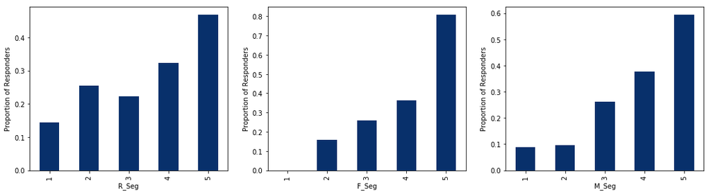

```python
import matplotlib.pyplot as plt
%matplotlib inline
fig = plt.figure(figsize=(18,4.5))

#  Recency VS Response
ax1=plt.subplot(131)
ax1=rfmSeg.groupby('R_Seg').agg('response').mean().plot(kind='bar', colormap='Blues_r')
ax1.set_xlabel("R_Seg")
ax1.set_ylabel("Proportion of Responders")
#  Frequency VS Response
ax2=plt.subplot(132)
ax2=rfmSeg.groupby('F_Seg').agg('response').mean().plot(kind='bar', colormap='Blues_r')
ax2.set_xlabel("F_Seg")
ax2.set_ylabel("Proportion of Responders")
#  Monetary VS Response
ax3=plt.subplot(133)
ax3=rfmSeg.groupby('M_Seg').agg('response').mean().plot(kind='bar', colormap='Blues_r')
ax3.set_xlabel("M_Seg")
ax3.set_ylabel("Proportion of Responders")
```

# 3 Modelling and Evaluation

## 3.1 Prepare Training Data

```python
from sklearn.model_selection import train_test_split
X = rfmSeg[['Recency', 'Frequency', 'Monetary']]
y = rfmSeg['response']
X_train, X_test, y_train, y_test = train_test_split(X, y, test_size=0.3, random_state=1)
```

```python
from sklearn.neighbors import KNeighborsClassifier
from sklearn.linear_model import LogisticRegression
from sklearn.svm import SVC
from sklearn.tree import DecisionTreeClassifier
from sklearn.ensemble import RandomForestClassifier, AdaBoostClassifier, GradientBoostingClassifier
from sklearn.naive_bayes import GaussianNB
from sklearn.neural_network import MLPClassifier
from sklearn.metrics import accuracy_score, roc_curve, auc

import matplotlib.pyplot as plt
%matplotlib inline
```

## 3.2 Train Model

```python
'''
Choose different classification algorithm, compare the result and choose the best one.
'''
classifiers = [
    KNeighborsClassifier(n_neighbors=5),
    LogisticRegression(),
    SVC(kernel='rbf', C=0.01, probability=True),
    DecisionTreeClassifier(),
    RandomForestClassifier(),
    AdaBoostClassifier(),
    GradientBoostingClassifier(),
    GaussianNB(),
    MLPClassifier(),
]

cols = ['Classifier', 'Accuracy', 'AUC']
results = pd.DataFrame(columns=cols)

for clf in classifiers:
    clf.fit(X_train, y_train)
    name = clf.__class__.__name__

    print('='*30)
    print(name)
    print('****Result****')
    y_pred = clf.predict(X_test)
    acc = accuracy_score(y_test, y_pred)
    print('Accuracy: {:.2%}'.format(acc))

    y_pred = clf.predict_proba(X_test)
    fpr, tpr, thresholds = roc_curve(y_test, y_pred[:,1])
    auc_value = auc(fpr, tpr)
    print('AUC: {0:0.2f}'.format(auc_value))

    # 保存模型计算结果
    result_clf = pd.DataFrame([[name, acc*100, auc_value]], columns=cols)
    results = results.append(result_clf)

print('*'*30)
```

```
==============================
KNeighborsClassifier
****Result****
Accuracy: 81.11%
AUC: 0.85
==============================
LogisticRegression
****Result****
Accuracy: 69.75%
AUC: 0.77
```

```
==============================
SVC
****Result****
Accuracy: 59.33%
AUC: 0.70
==============================
DecisionTreeClassifier
****Result****
Accuracy: 76.80%
AUC: 0.76
```

```
==============================
RandomForestClassifier
****Result****
Accuracy: 80.72%
AUC: 0.87
==============================
AdaBoostClassifier
****Result****
Accuracy: 83.70%
AUC: 0.90
==============================
GradientBoostingClassifier
****Result****
Accuracy: 84.01%
AUC: 0.90
==============================
GaussianNB
****Result****
Accuracy: 67.71%
AUC: 0.77
==============================
MLPClassifier
****Result****
Accuracy: 70.69%
AUC: 0.82
```

```python
results
```

[output not shown]

```python
best_clf = GradientBoostingClassifier()
best_clf.fit(X_train, y_train)
```

```
GradientBoostingClassifier(criterion='friedman_mse', init=None,
              learning_rate=0.1, loss='deviance', max_depth=3,
              max_features=None, max_leaf_nodes=None,
              min_impurity_decrease=0.0, min_impurity_split=None,
              min_samples_leaf=1, min_samples_split=2,
              min_weight_fraction_leaf=0.0, n_estimators=100,
              n_iter_no_change=None, presort='auto', random_state=None,
              subsample=1.0, tol=0.0001, validation_fraction=0.1,
              verbose=0, warm_start=False)
```

```python
def gainTable(y_true_int, y_pred_prob):
    """
    y_true_int:
    y_pred_prob: predict probability
    return: DataFrame
    """
    data = pd.DataFrame({'y_true': y_true_int, 'prob': y_pred_prob})
    data['prob'] = 1 - data['prob']
    data['percentile_gp'] = pd.qcut(data['prob'], q=10, labels=range(10))
    deciles = data.groupby('percentile_gp', sort=True)
    def total_count(x): return len(x)
    def pos_count(x): return np.sum(x)

    # positive rate
    def pos_rate(x): return np.sum(x)/float(len(x))
    out = deciles['y_true'].agg([total_count, pos_count, pos_rate])

    # negitive
    out['neg_count'] = out['total_count'] - out['pos_count']

    # positive total sum
    out['pos_cumsum'] = out['pos_count'].cumsum()
    total_sum = out['pos_cumsum'][-1]

    # positive cover rate
    out['pos_cover_rate'] = out['pos_cumsum'] / float(total_sum)
    out['percentile'] = (out.index.astype(int) + 1) / 10.0
    return out[['percentile', 'total_count', 'pos_count', 'neg_count', 'pos_rate', 'pos_cover_rate']]
```

```python
def plotGainChart(GainTable):
    plt.plot(GainTable['percentile'], GainTable['pos_cover_rate'], 'g-')
    plt.plot(GainTable['percentile'], GainTable['percentile'], 'r--')
    plt.legend(['model', 'random'])
    plt.show()
```

```python
# Predict test dataset X_test, get positive probability
y_prob = best_clf.predict_proba(X_test)[:,1]

gainTable = gainTable(y_test, y_prob)
gainTable
```

| percentile_gp | percentile | total_count | pos_count | neg_count | pos_rate | pos_cover_rate |
| --- | --- | --- | --- | --- | --- | --- |
| 0 | 0.1 | 128 | 123 | 5 | 0.960938 | 0.162483 |
| 1 | 0.2 | 128 | 120 | 8 | 0.937500 | 0.321004 |
| 2 | 0.3 | 127 | 118 | 9 | 0.929134 | 0.476882 |
| 3 | 0.4 | 129 | 107 | 22 | 0.829457 | 0.618230 |
| 4 | 0.5 | 126 | 104 | 22 | 0.825397 | 0.755614 |
| 5 | 0.6 | 128 | 89 | 39 | 0.695312 | 0.873184 |
| 6 | 0.7 | 127 | 49 | 78 | 0.385827 | 0.937913 |
| 7 | 0.8 | 130 | 25 | 105 | 0.192308 | 0.970938 |
| 8 | 0.9 | 127 | 19 | 108 | 0.149606 | 0.996037 |
| 9 | 1.0 | 126 | 3 | 123 | 0.023810 | 1.000000 |

```python
plotGainChart(gainTable)
```

[output not shown]

```python
y_prob
```

```
array([0.61264346, 0.92416017, 0.96631035, ..., 0.95499611, 0.01917968,
       0.06962162])
```

```python
"""
save model
"""
import pickle
with open('response_model.pickle', 'wb') as fw:
    pickle.dump(best_clf, fw)
```

## 4 Deployment

```python
"""
load saved model
"""
import pickle
with open('response_model.pickle', 'rb') as fr:
    model = pickle.load(fr)
```

```python
import pandas as pd
import numpy as np
import datetime

# get dataset for prediction
df = OR_df

df = df.replace([0.00, np.inf, -np.nan], np.nan)
df = df.dropna(subset=['Price', 'Customer ID', 'Quantity']).reset_index()
df['Invoice'] = df['Invoice'].astype(str).str.replace('C', '').astype(int)

new_df = pd.DataFrame()
new_df['Invoice'] = df.loc[:, 'Invoice'].astype(int)
new_df['StockCode'] = df.loc[:, 'StockCode'].astype(str)
new_df['Description'] = df.loc[:, 'Description'].astype(str)
new_df['Quantity'] = df.loc[:, 'Quantity']
new_df['InvoiceDate'] = pd.to_datetime(df.loc[:, 'InvoiceDate'])
new_df['Price'] = df.loc[:, 'Price']
new_df['CustomerID'] = df.loc[:, 'Customer ID'].astype(int)
new_df['Country'] = df.loc[:, 'Country'].astype(str)

new_df['Cost'] = new_df['Quantity']*new_df['Price']
customer_count = len(new_df.CustomerID.value_counts())

# datetime type
import datetime
now_time = datetime.datetime(2012,1,1)
new_df['hist'] = now_time-new_df['InvoiceDate']        # 时间差类型为('timedelta64[D]')
new_df['hist'] = new_df['hist']/np.timedelta64(1, 'D') # 将时间差转化为float
new_df.head()
```

|  | Invoice | StockCode | Description | Quantity | InvoiceDate | Price | CustomerID | Country | Cost | hist |
| --- | --- | --- | --- | --- | --- | --- | --- | --- | --- | --- |
| 0 | 489434 | 85048 | 15CM CHRISTMAS GLASS BALL 20 LIGHTS | 12 | 2009-12-01 07:45:00 | 6.95 | 13085 | United Kingdom | 83.4 | 760.677083 |
| 1 | 489434 | 79323P | PINK CHERRY LIGHTS | 12 | 2009-12-01 07:45:00 | 6.75 | 13085 | United Kingdom | 81.0 | 760.677083 |
| 2 | 489434 | 79323W | WHITE CHERRY LIGHTS | 12 | 2009-12-01 07:45:00 | 6.75 | 13085 | United Kingdom | 81.0 | 760.677083 |
| 3 | 489434 | 22041 | RECORD FRAME 7" SINGLE SIZE | 48 | 2009-12-01 07:45:00 | 2.10 | 13085 | United Kingdom | 100.8 | 760.677083 |
| 4 | 489434 | 21232 | STRAWBERRY CERAMIC TRINKET BOX | 24 | 2009-12-01 07:45:00 | 1.25 | 13085 | United Kingdom | 30.0 | 760.677083 |

```python
new_df.info()
```

```
<class 'pandas.core.frame.DataFrame'>
RangeIndex: 417503 entries, 0 to 417502
Data columns (total 10 columns):
Invoice        417503 non-null int64
StockCode      417503 non-null object
Description    417503 non-null object
Quantity       417503 non-null int64
InvoiceDate    417503 non-null datetime64[ns]
Price          417503 non-null float64
CustomerID     417503 non-null int64
Country        417503 non-null object
Cost           417503 non-null float64
hist           417503 non-null float64
dtypes: datetime64[ns](1), float64(3), int64(3), object(3)
memory usage: 31.9+ MB
```

```python
"""
create rfm score table
"""
rfmTable = new_df.groupby('CustomerID').agg({
    'hist':'min',
    'CustomerID':'count',
    'Cost':'sum'
})

rfmTable.rename(columns={'hist':'Recency',
                         'CustomerID':'Frequency',
                         'Cost':'Monetary'}, inplace=True)
```

```python
rfmTable.head()
```

| CustomerID | Recency | Frequency | Monetary |
| --- | --- | --- | --- |
| 12346 | 453.310417 | 46 | -64.68 |
| 12347 | 389.377083 | 71 | 1323.32 |
| 12348 | 460.375694 | 20 | 222.16 |
| 12349 | 429.650694 | 107 | 2646.99 |
| 12351 | 397.359028 | 21 | 300.93 |

```python
"""
predict the probability
"""
prediction = model.predict_proba(rfmTable)[:,1]
prediction = pd.DataFrame(prediction, columns=['response_probability'])
prediction.head()
```

|  | response_probability |
| --- | --- |
| 0 | 0.476809 |
| 1 | 0.968757 |
| 2 | 0.757411 |
| 3 | 0.966447 |
| 4 | 0.802020 |

```python
prediction = pd.concat([rfmTable.reset_index(drop=False), prediction], axis=1)
prediction = prediction.set_index('CustomerID') #set Customer Id as index of dataframe
prediction = prediction.sort_values(by=['response_probability'], ascending=False) #sort by response_proba, desc
prediction.head()
```

| CustomerID | Recency | Frequency | Monetary | response_probability |
| --- | --- | --- | --- | --- |
| 12805 | 403.481250 | 58 | 1434.95 | 0.986652 |
| 15590 | 404.382639 | 87 | 1496.60 | 0.986652 |
| 14555 | 403.517361 | 100 | 1982.34 | 0.986652 |
| 14327 | 404.358333 | 94 | 1583.28 | 0.986652 |
| 12849 | 403.513194 | 97 | 2039.67 | 0.986652 |

```python
records = len(prediction)
target_rocords = int(0.3*records)
target_customer = prediction.iloc[:target_rocords,]
target_customer.head()
```

| CustomerID | Recency | Frequency | Monetary | response_probability |
| --- | --- | --- | --- | --- |
| 12805 | 403.481250 | 58 | 1434.95 | 0.986652 |
| 15590 | 404.382639 | 87 | 1496.60 | 0.986652 |
| 14555 | 403.517361 | 100 | 1982.34 | 0.986652 |
| 14327 | 404.358333 | 94 | 1583.28 | 0.986652 |
| 12849 | 403.513194 | 97 | 2039.67 | 0.986652 |

```python
records
```

```
4381
```

```python
target_customer.to_csv('target_customer.csv')
```